# Plants in Space Assignment 1

## Data

```r
rna = read_table2("plants_in_space_rnaseq_counts.txt")
```

1. Determine the sum of all counts within each plate of the experiment (column of the RNA-Seq counts matrix). Summarize these counts numerically (mean, median, standard deviation, minimum, maximum) and graphically. In your graph, indicate both condition (space flight or ground) and ecotype. (To get the data into a proper format for plotting, you will need to reshape the count summaries and either join with variables from the design file or extract the variables from the column names).

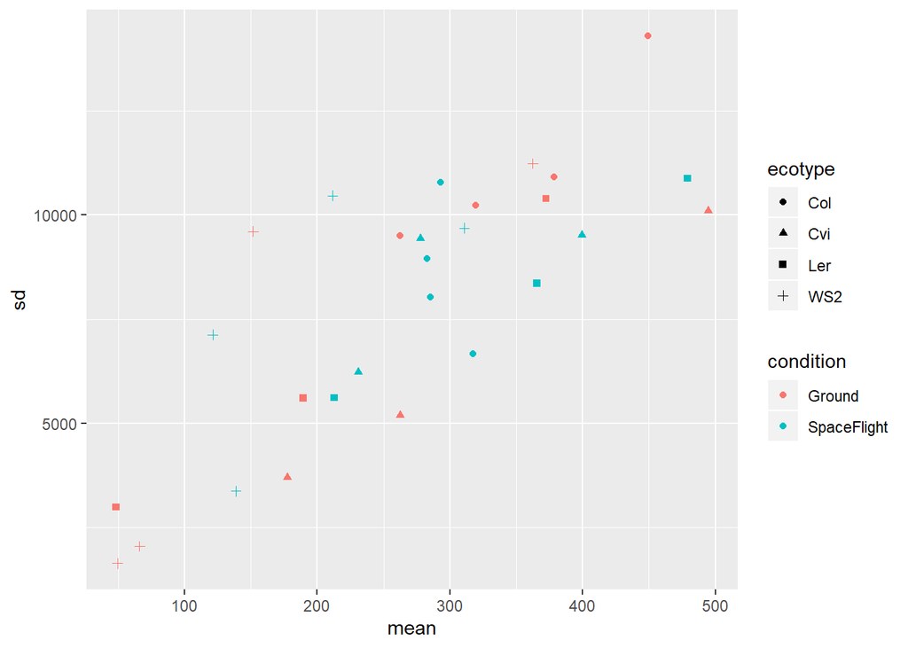

```r
rna_q1 = rna%>%
    select(ID,everything()) %>%
    pivot_longer(cols = -ID, names_to = "plate", values_to = "counts") %>%
    separate(plate, into = c("ecotype","condition","replicate"), remove = FALSE)%>%
    group_by(plate)%>%
    mutate(sum = sum(counts), mean = mean(counts), sd = sd(counts), median = median(counts), min = min(counts),max = max(counts))

rna_q1 %>%
    select(plate, mean, sd, condition, ecotype)%>%
    group_by(plate)%>%
    ggplot(aes(x = mean, y = sd, color = condition, shape = ecotype))+geom_point()
```

2. If the sampling proportions differ only by the intensity of sampling, we would expect counts from two different biological replicates under the same conditions to be proportional. A graph of counts from one to the other would be roughly on a straight line. Plot the counts from biological replicates 1 and 2 from the Col-0 ecotype under the space flight condition. Add smooth curve through the scatter plot. Does it appear that one set of counts is roughly proportional to the other, or are there some inconsistencies for some isoforms? *Hint: consider using the log-transformation for the counts which are positive and consinder using `geom_hex()` from the `hexbin` package to improve the display of the plot.*

It seems that there is a linear relationship between biological replicates and count sizes, indicating that counts are generally proportional between replicates. However, there were several major outliers in the data, which I removed in order to see the trend better. It seems that the greater the number of counts from one replicate that are found, the less able you are to predict the number of counts from the other replicate.

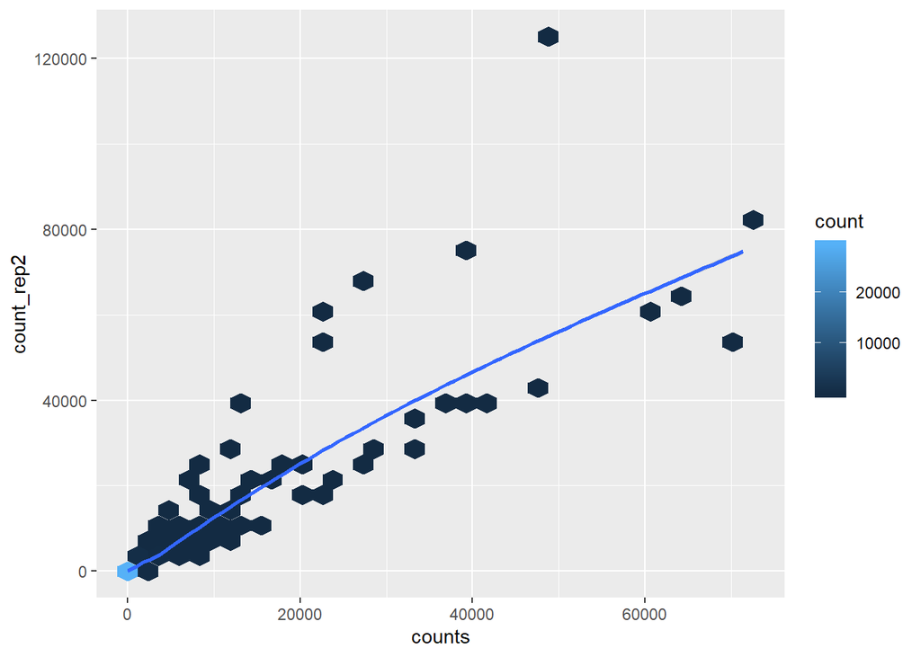

```r
rna_q2 = rna_q1%>%
    select(condition, ecotype, replicate, counts, ID)%>%
    filter(condition == "SpaceFlight" & ecotype == "Col" & counts > 0 & (replicate == 1 | replicate == 2))%>%
    group_by(ID)%>%
    mutate(sum1 = sum(counts),
           count_rep2 = sum1- counts)%>%
    select(-sum1)%>%
    ungroup()%>%
    filter(replicate == 1)
rna_q2%>%
    filter(counts<75000)%>%
    ggplot(aes(x=counts,y=count_rep2))+geom_hex()+geom_smooth()
```

3. Create a new variable to the raw counts data frame named `chromosome` which is the third character of the `ID`. (Hint. Use the function `str_sub()` from the `stringr` package.)

```r
rna_q3 = rna_q2%>%
    mutate(chromosome = str_sub(ID, start = 3, end = 3))
```

4. How many isoforms are there for each chromosome? Sort from totals from largest to smallest.

```r
rna_q4 = rna_q3%>%
    group_by(chromosome)%>%
    summarize(sum(counts))
```

[output not shown]

5. Determine the sum of all normalized counts within each plate of the experiment. Plot these total normalized counts, indicating condition (space flight or ground), ecotype, and replicate. How does this plot compare to the similar plot of the raw counts?

This plot is much more concise and does a much better job showing outliers in the data.

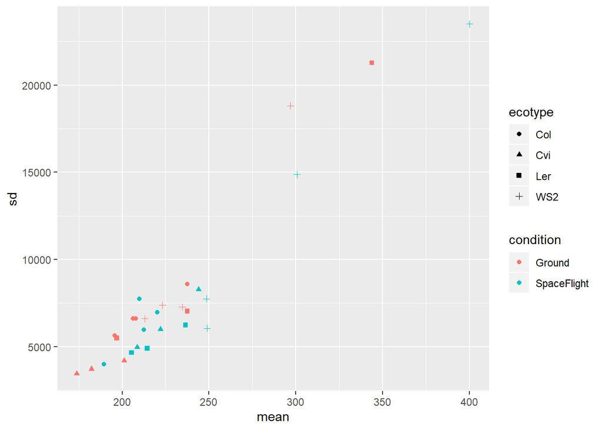

```r
#create cts dataframe
cts = rna %>%
  select(-ID) %>%
  as.matrix()
rownames(cts) = rna$ID
colnames(cts) =
#scale factor
sf = estimateSizeFactorsForMatrix(cts)
mat = matrix(sf, byrow=TRUE, nrow = nrow(cts), ncol = ncol(cts))
ncounts = cts / mat
rm(mat)
#new tibble using scale factor
colnames(ncounts) = names(rna)[-1]
rna_n = as_tibble(ncounts) %>%
  mutate(id = rna$ID) %>%
  select(id,everything()) %>%
  pivot_longer(cols = -id, names_to = "plate", values_to = "counts") %>%
  separate(plate, into = c("ecotype","condition","replicate"), remove = FALSE)
#sum by plate
rna_q5 = rna_n%>%
    group_by(plate)%>%
    mutate(sum = sum(counts), mean = mean(counts), sd = sd(counts), median = median(counts), min = min(counts),max = max(counts))

rna_q5 %>%
    select(plate, mean, sd, condition, ecotype)%>%
    group_by(plate)%>%
    ggplot(aes(x = mean, y = sd, color = condition, shape = ecotype))+geom_point()
```

6. For each ecotype, condition, and isoform, find average of the (3 or 4) normalized counts. (Average over the biological replicates of for each ecotype in each condition.) Then make a plot of the base 10 logs of these counts with ground on the x-axis and space flight on the y-axis, using a different facet for each ecotype. Describe any patterns you see.

There seems to be a positive trend in each plot, but the Col ecotype seems to be the highest correlated.

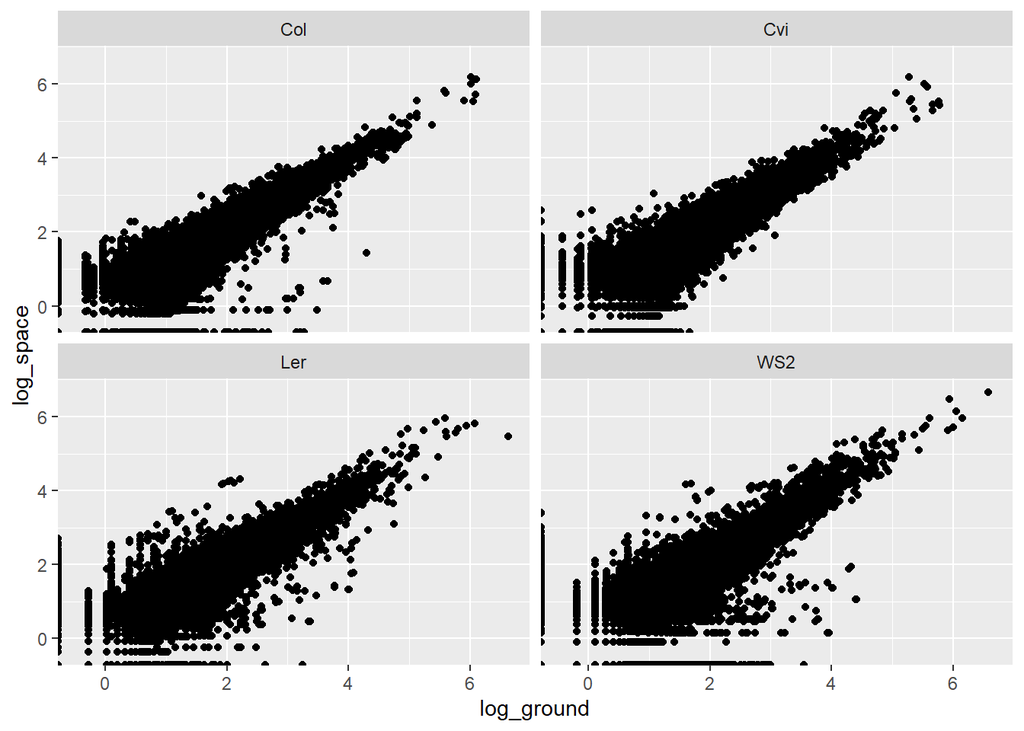

```r
rna_q6_avgs = rna_n%>%
    select(-plate)%>%
    group_by(ecotype, condition, replicate)%>%
    summarize(mean = mean(counts))

rna_q6 = rna_n%>%
    select(-plate)%>%
    group_by(id, ecotype, replicate)%>%
    pivot_wider(names_from = condition, values_from = counts)%>%
    mutate(log_space = log10(SpaceFlight),
           log_ground = log10(Ground))
rna_q6%>%
    ggplot(aes(x = log_ground, y = log_space))+geom_point()+facet_wrap(~ecotype)
```

7. Repeat the previous problem, but first install the package `hexbin` and use the function `geom_hexbin()` instead of `geom_point()`. Compare these two plots. What are the pros and cons of each?

The hexbin plot shows density much better than the dot plot. However, it is more difficult to see how many zeros are in the data with the hex plot.

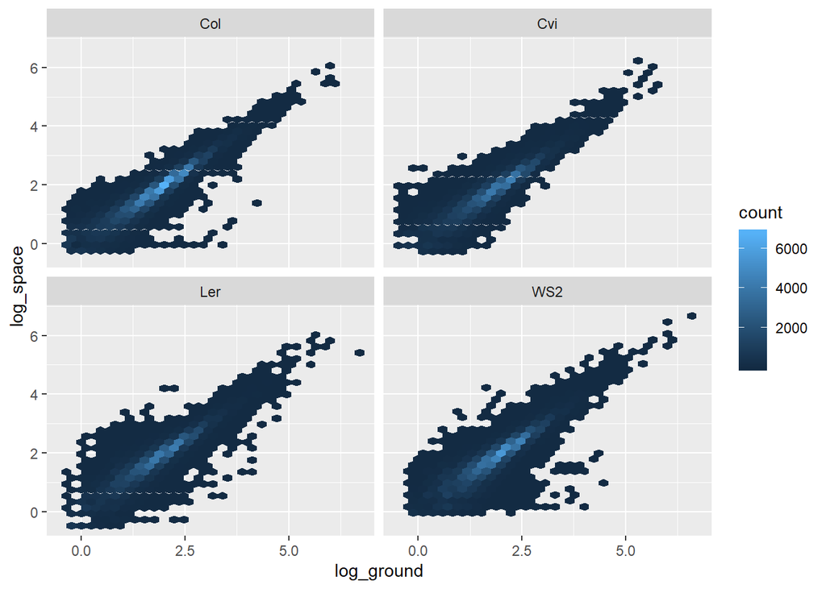

```r
rna_q7 = rna_n%>%
    select(-plate)%>%
    group_by(id, ecotype, replicate)%>%
    pivot_wider(names_from = condition, values_from = counts)%>%
    mutate(log_space = log10(SpaceFlight),
           log_ground = log10(Ground))
rna_q7%>%
    ggplot(aes(x = log_ground, y = log_space))+geom_hex()+facet_wrap(~ecotype)
```

8. Write code to mimic the built in MA plot from `DESeq2`, but use `ggplot2`.
- The columns of `resLFC` are:
  - `baseMean`
  - `log2FoldChange`
  - `lfcSE`
  - `pvalue`
  - `padj`
- The column `padj` has adjusted p-values which takes false discovery rate and differential expression into account
- Your plot should:
  - have `log2FoldChange` on the y axis
  - have the base ten log of `baseMean` on the x axis
  - for points outside the limits, use:
    - pch = 2, the up-pointing triangle, for any points above the maximum y limit
    - pch = 6, the down-pointing triangle, for any pints below the minimum y limitn
  - use a period (dot) as the plotting character for points with y-values within the limits
  - color points:
    - black if the adjusted p-value `padj` is greater than or equal to 0.1
    - red if the adjusted p-value `padj` is less than 0.1
  - add a red horizontal line with a y-intercept of 0 (and alpha = 0.5)
  - use the `theme_bw()` black and white theme
  - create readable labels
  - use good tick labels (without scientifi notation)

```r
cts = rna %>%
  select(-ID) %>%
  as.matrix()
rownames(cts) = rna$ID

## create a data frame col_data with the information for each column
## create it from rna to be sure it matches
col_data = tibble( names = names(rna)[-1] ) %>%
  separate(names, into = c("ecotype","condition","replicate"), remove = FALSE) %>%
  column_to_rownames(var = "names")

## check that names match and are in the same order
all( rownames(col_date) == colnames(cts) )
```

```
## [1] TRUE
```

```r
## Create the DESeq2 object
## Note the design formula design = ~ ecotype + condition
## The primary factor of interest should come last
dds = DESeqDataSetFromMatrix(countData = cts,
                             colData = col_data,
                             design = ~ ecotype + condition)

## Prefiltering
## The package authors recommend getting rid of any genes where the sum of total counts is small to avoid spurious results where there is little signal and power
## Here, filter to only keep rows where the total counts are 20 or more
## See how many genes this eliminates from the analysis

## before
nrow(dds)
```

```
## [1] 41671
```

```r
keep = rowSums(counts(dds)) >= 20
dds = dds[keep,]

## after
nrow(dds)
```

```
## [1] 31483
```

```r
dds = DESeq(dds)
res = results(dds)


resLFC = lfcShrink(dds, coef = "condition_SpaceFlight_vs_Ground", type = "apeglm")
## reorder genes from smallest to largest pvalue
resLFC = resLFC[order(resLFC$pvalue),]


resLFC = resLFC%>%
    as_tibble()
#ggplot(data = filter(resLFC, log2))
```

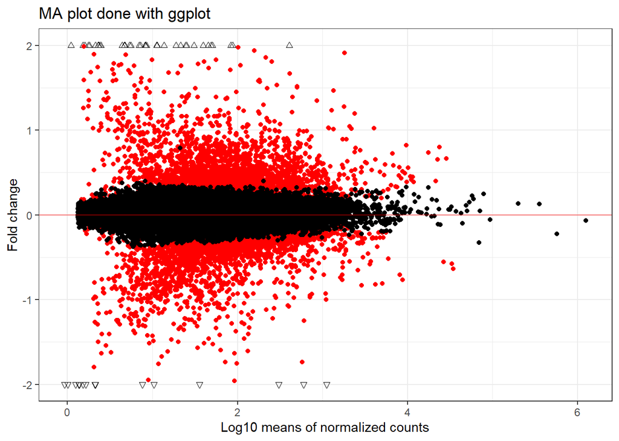

```r
resLFC = resLFC%>%
    as_tibble()

ggplot()+
  geom_point(data = filter(resLFC, log2FoldChange >2),
             aes(x = log10(baseMean), y = 2), shape = 2)+
  geom_point(data = filter(resLFC, log2FoldChange < -2),
             aes(x = log10(baseMean), y = -2), shape = 6)+
  geom_point(data = filter(resLFC, padj <=0.1 & log2FoldChange > -2 & log2FoldChange < 2),
             aes(x = log10(baseMean), y = log2FoldChange), color = "red")+
  geom_point(data = filter(resLFC, padj >0.1 & log2FoldChange > -2 & log2FoldChange < 2),
             aes(x = log10(baseMean), y = log2FoldChange), color = "black")+
  coord_cartesian(ylim = c(-2,2))+
  geom_abline(slope = 0, intercept = 0, alpha = 0.5, color = "red")+
  theme_bw()+
  xlab("Log10 means of normalized counts")+
  ylab("Fold change")+
  ggtitle("MA plot done with ggplot")
```